# understanding how lasso regression works

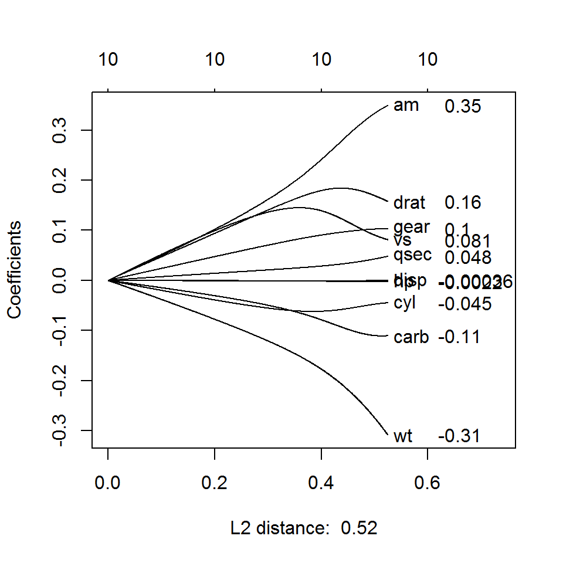

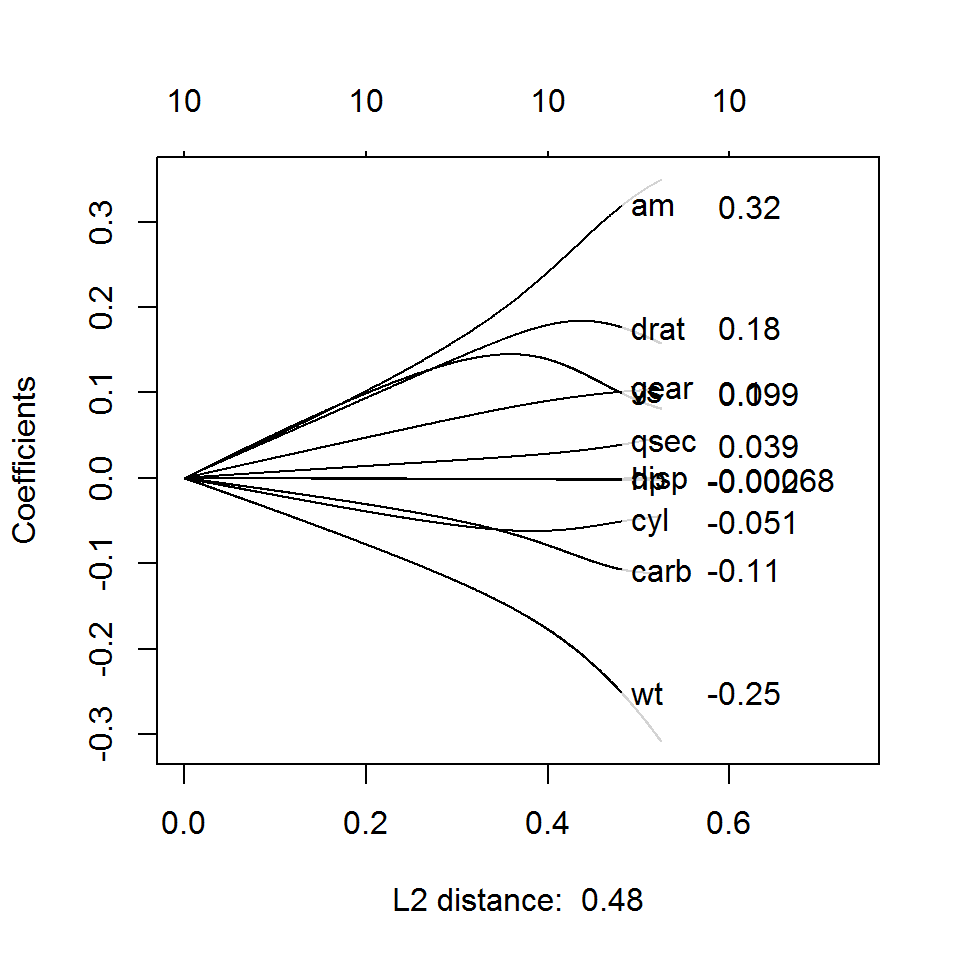

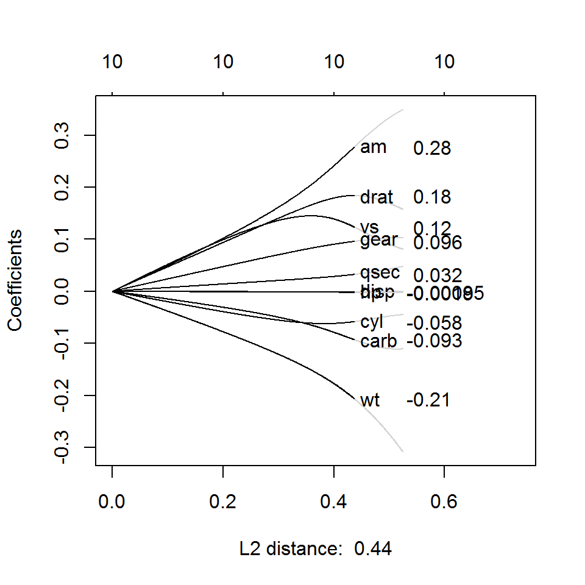

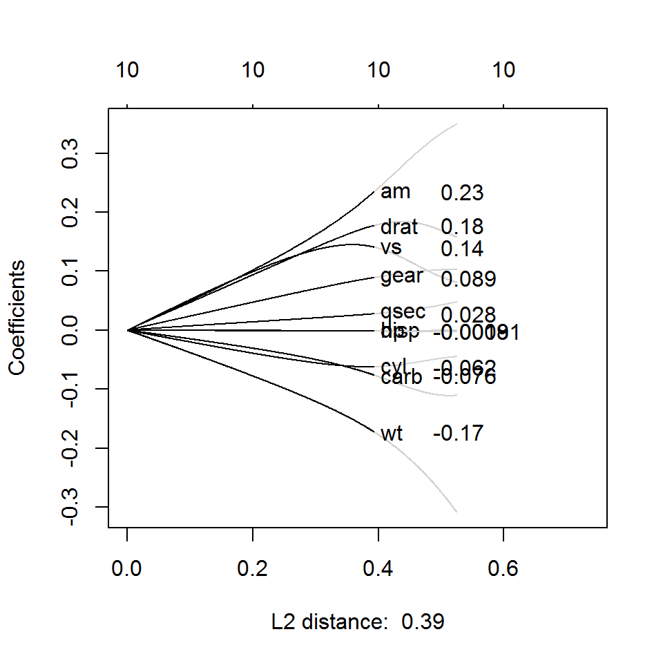

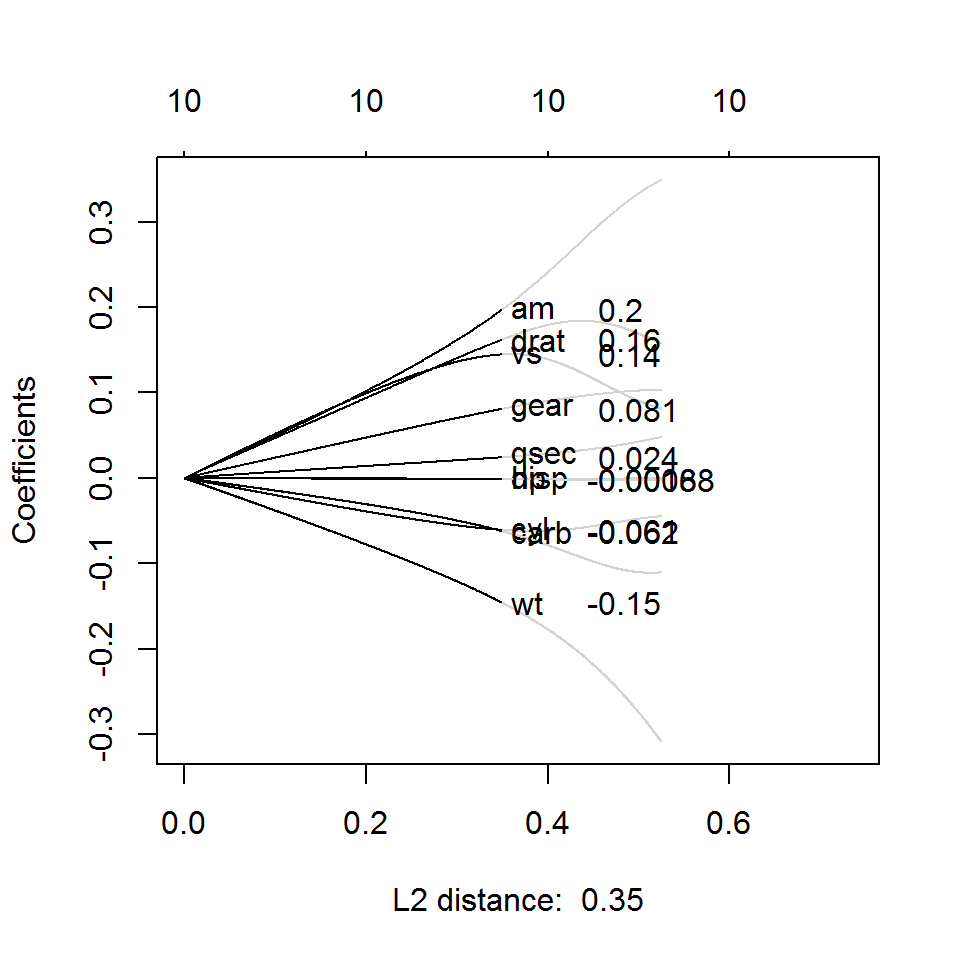

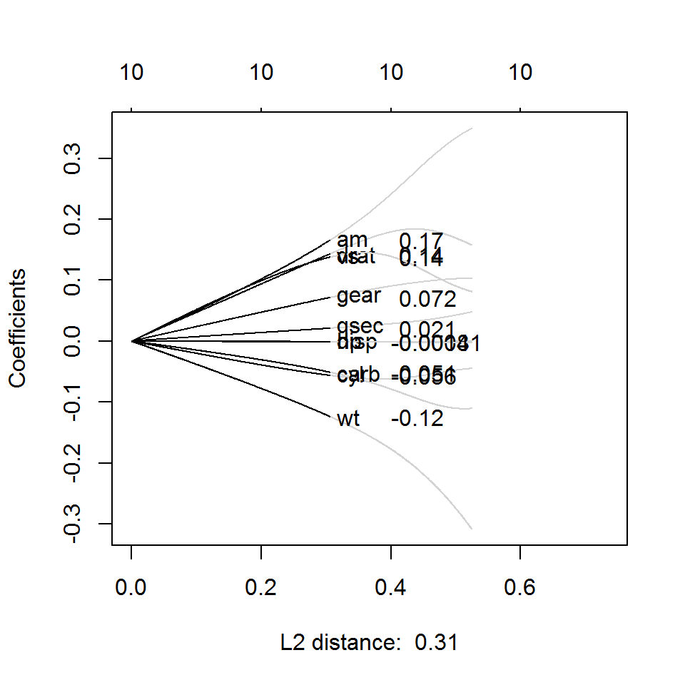

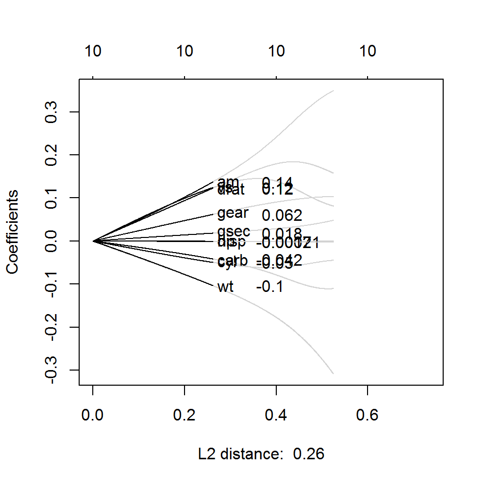

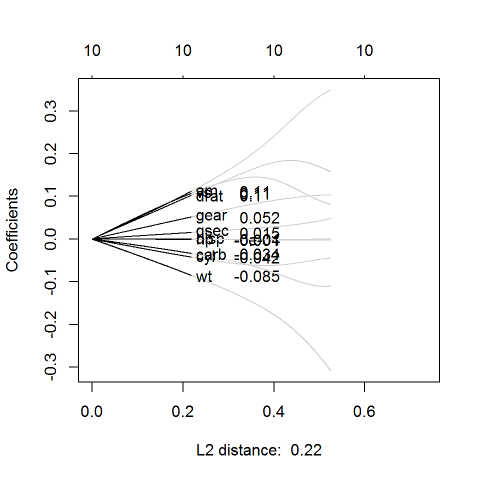

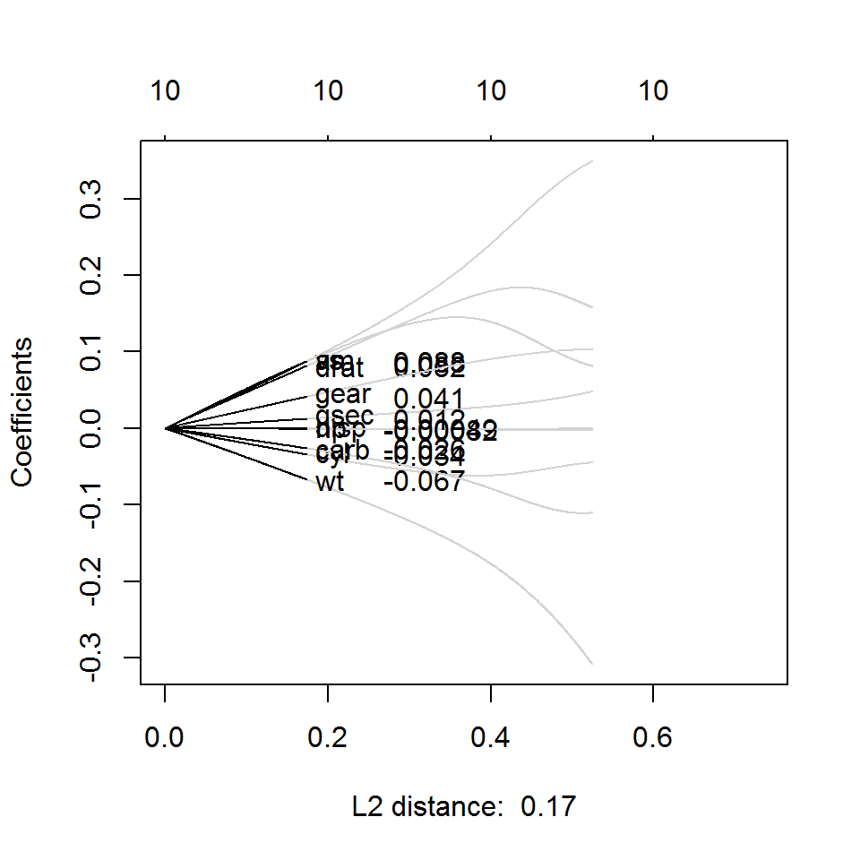

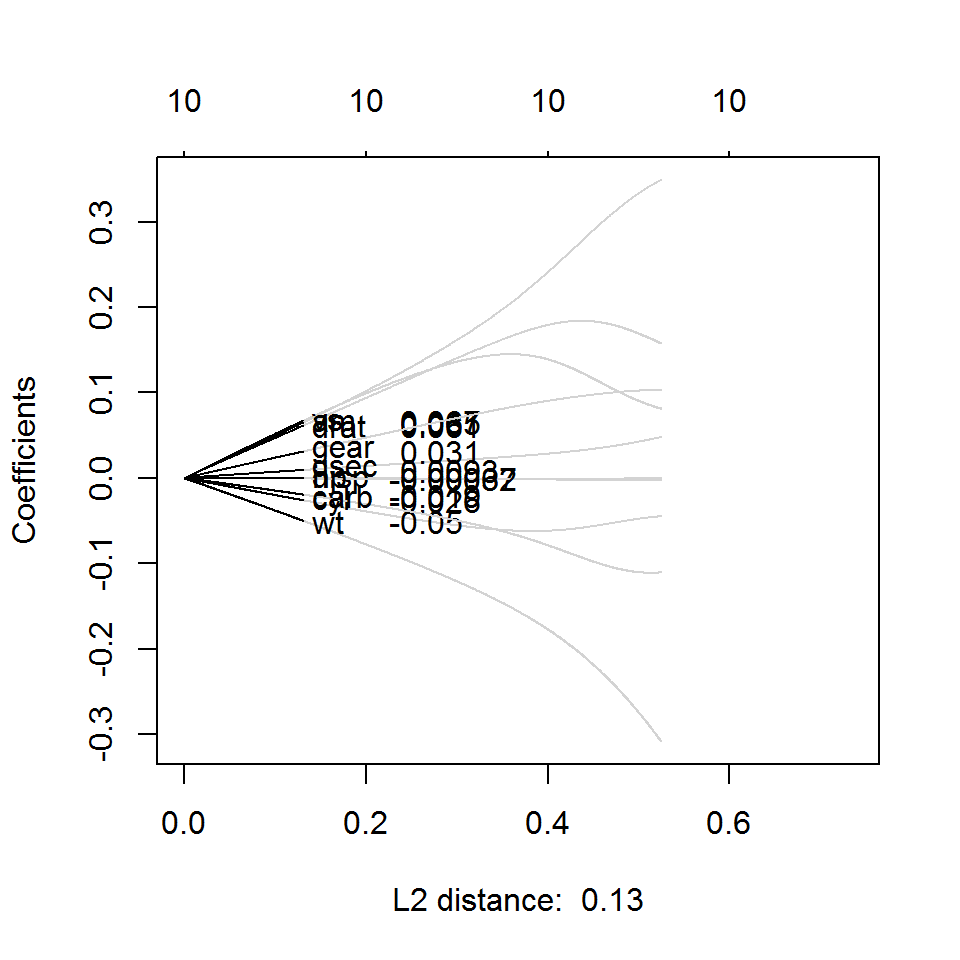

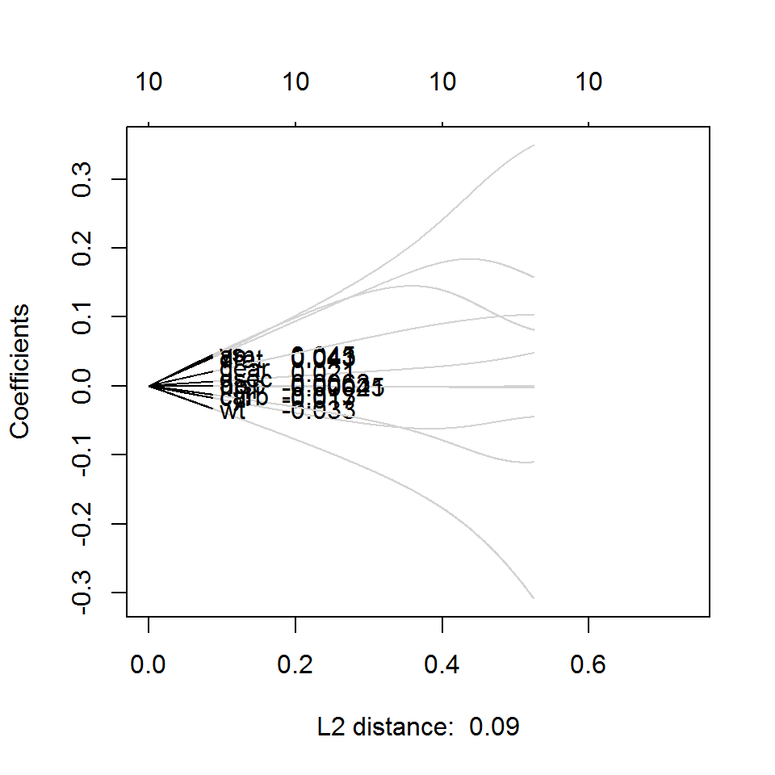

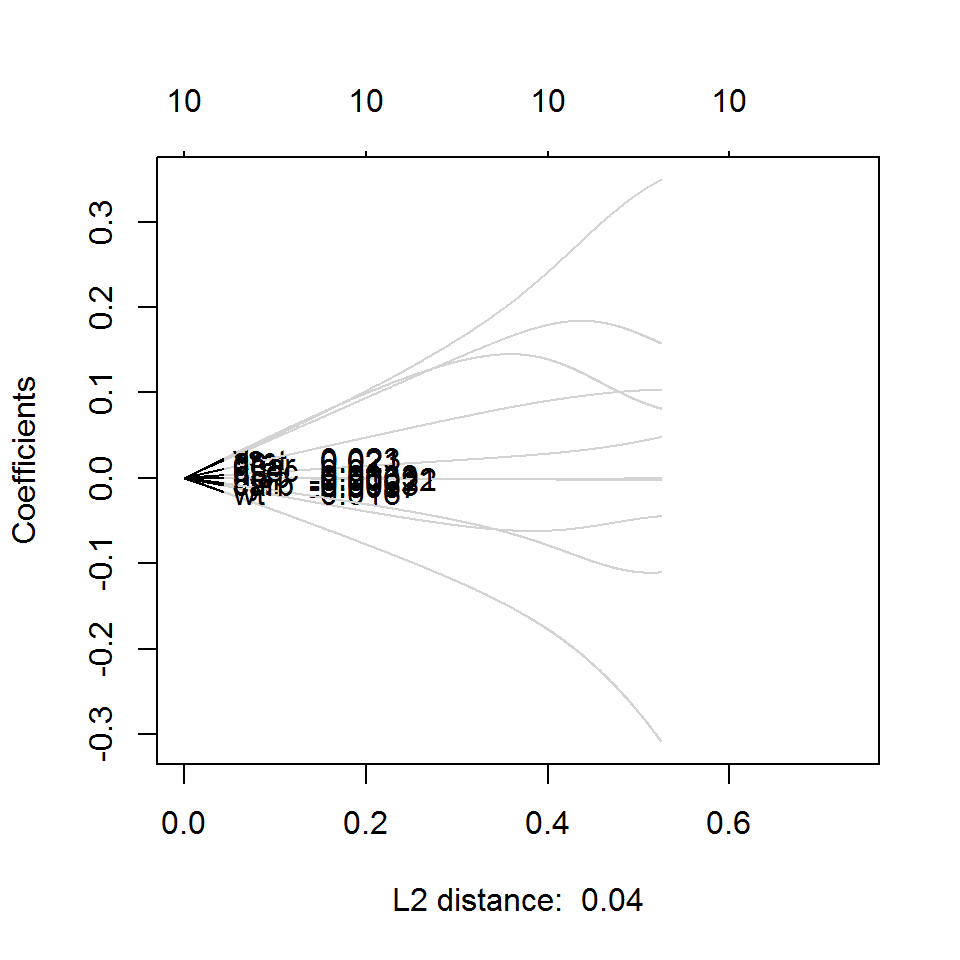

```r
ridge <- glmnet(as.matrix(mtcars[, -1]), standardize(mtcars[, 1]), alpha=0, intercept=FALSE, nlambda=1000)
m_ridge <- dim(ridge$beta)[2]
l2_dist <- apply(ridge$beta, 2, function(x) sqrt(sum(x^2)))
d1 <- 0.02*l2_dist[m_ridge]
d2 <- 0.18*l2_dist[m_ridge]
for (l in 12:1) {
  fraction <- l/12
  j <- max(which(l2_dist <= fraction*l2_dist[m_ridge]))
  xl <- paste("L2 distance: ", round(l2_dist[j], 2))
  plot(ridge, xlim=c(0, 1.4*max(l2_dist)),type="n", xlab=xl)
  offset <- strwidth("-", units="user")
  for (i in 1:n) {
    lines(l2_dist[1:m_ridge], ridge$beta[i, 1:m_ridge], col="lightgray")
    lines(l2_dist[1:j], ridge$beta[i, 1:j])
    if (abs(ridge$beta[i,j]) > 0) {
      text(d1+l2_dist[j], ridge$beta[i, j], names(mtcars[i+1]), adj=0)
      text(d2+l2_dist[j]+(ridge$beta[i, j]>0)*offset, ridge$beta[i, j], signif(ridge$beta[i, j], 2), adj=0)
    }
  }
}
```

You can also compare this to stepwise regression. Let’s look at backwards elimination, because it is the easiest to program.

```r
library("broom")
library("dplyr")
library("magrittr")
library("RColorBrewer")
mtcars.s <- data.frame(sapply(mtcars, standardize))
co <- data.frame(co=brewer.pal(10, "Set3"), term=names(mtcars.s)[-1], stringsAsFactors=FALSE)
iv.list <- names(mtcars.s)[-1]
m0 <- NULL
i <- 0
while (i < 10) {
  iv <- paste(iv.list, collapse=" + ")
  dv <- names(mtcars.s)[1]
  fo <- as.formula(paste(dv, " ~ ", iv, " - 1", sep=""))
  lm(fo, data=mtcars.s)          %>%
    tidy                         %>%
    full_join(co)                %>%
    arrange(desc(p.value))       %>%
    mutate(step=length(iv.list))  -> m1
  m1 %>%
    slice(1)                        %>%
    mutate(abs.t=abs(statistic))    %>%
    select(step, abs.t)             %>%
    inner_join(m1)                   -> m2
  m0 %<>% bind_rows(m2)
  iv.list %<>% setdiff(m1$term[1])
  print(iv.list)
  i <- i+1
}
```

```
## [1] "disp" "hp"   "drat" "wt"   "qsec" "vs"   "am"   "gear" "carb"
```

```
## [1] "disp" "hp"   "drat" "wt"   "qsec" "am"   "gear" "carb"
```

```
## [1] "disp" "hp"   "drat" "wt"   "qsec" "am"   "gear"
```

```
## [1] "disp" "hp"   "drat" "wt"   "qsec" "am"
```

```
## [1] "disp" "hp"   "wt"   "qsec" "am"
```

```
## [1] "hp"   "wt"   "qsec" "am"
```

```
## [1] "wt"   "qsec" "am"
```

```
## [1] "wt"   "qsec"
```

```
## [1] "wt"
```

```
## character(0)
```

```r
m0$estimate[is.na(m0$estimate)] <- 0
m0
```

```
##     step     abs.t term    estimate  std.error   statistic      p.value
## 1     10 0.1091487  cyl -0.03302235 0.30254450  -0.1091487 9.140740e-01
## 2     10 0.1091487   vs  0.02657358 0.17194755   0.1545447 8.785893e-01
## 3     10 0.1091487 carb -0.05344363 0.21699614  -0.2462884 8.077424e-01
## 4     10 0.1091487 gear  0.08023404 0.17859830   0.4492430 6.576508e-01
## 5     10 0.1091487 drat  0.06982829 0.14174594   0.4926300 6.271548e-01
## 6     10 0.1091487 disp  0.27422706 0.35878018   0.7643317 4.527903e-01
## 7     10 0.1091487   hp -0.24438168 0.24194682  -1.0100636 3.234456e-01
## 8     10 0.1091487 qsec  0.24343220 0.21170776   1.1498502 2.625523e-01
## 9     10 0.1091487   am  0.20865790 0.16636195   1.2542405 2.229178e-01
## 10    10 0.1091487   wt -0.60316876 0.30048152  -2.0073406 5.715317e-02
## 11     9 0.2045734   vs  0.03259365 0.15932496   0.2045734 8.397050e-01
## 12     9 0.2045734 carb -0.05884748 0.20668477  -0.2847210 7.784058e-01
## 13     9 0.2045734 gear  0.08710673 0.16350110   0.5327593 5.993104e-01
## 14     9 0.2045734 drat  0.07409419 0.13329243   0.5558769 5.836626e-01
```

[output cut: 187 more lines]

```r
tint <- seq(min(m0$abs.t), max(m0$abs.t), by=0.01)
abs.t <- rep(tint[1], length(tint))
for (tseq  in sort(unique(m0$abs.t))) {
  abs.t[tint > tseq] <- tseq
}

data.frame(tint=tint, abs.t=abs.t) %>%
  inner_join(m0) -> m3
```

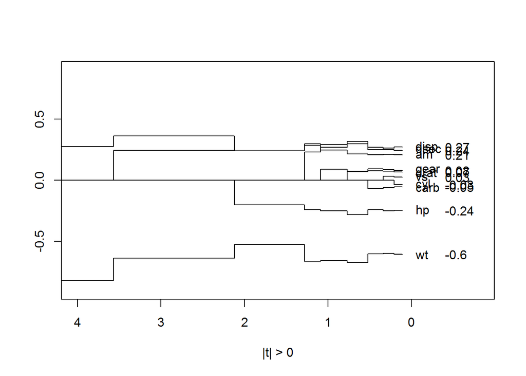

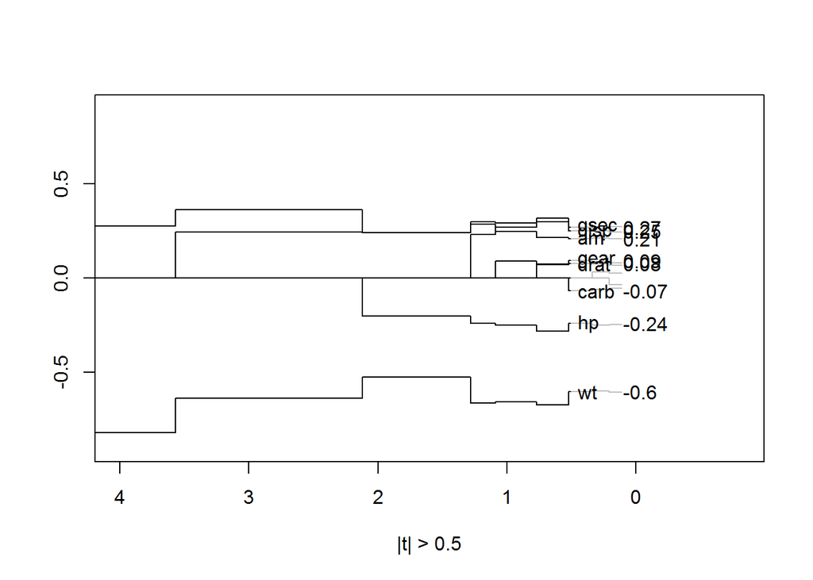

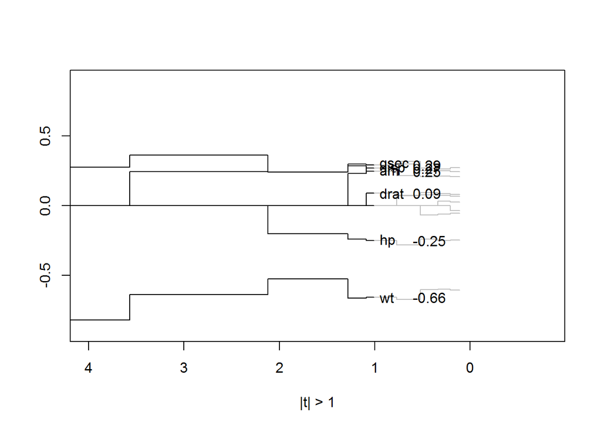

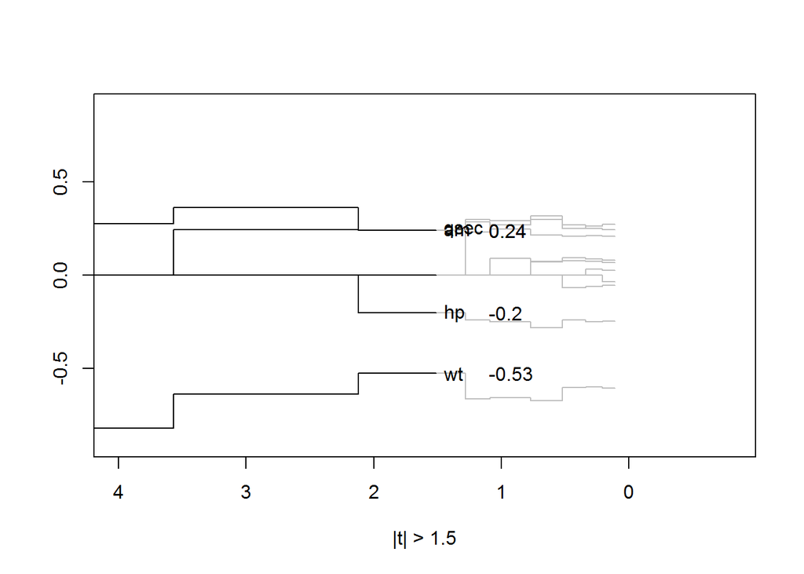

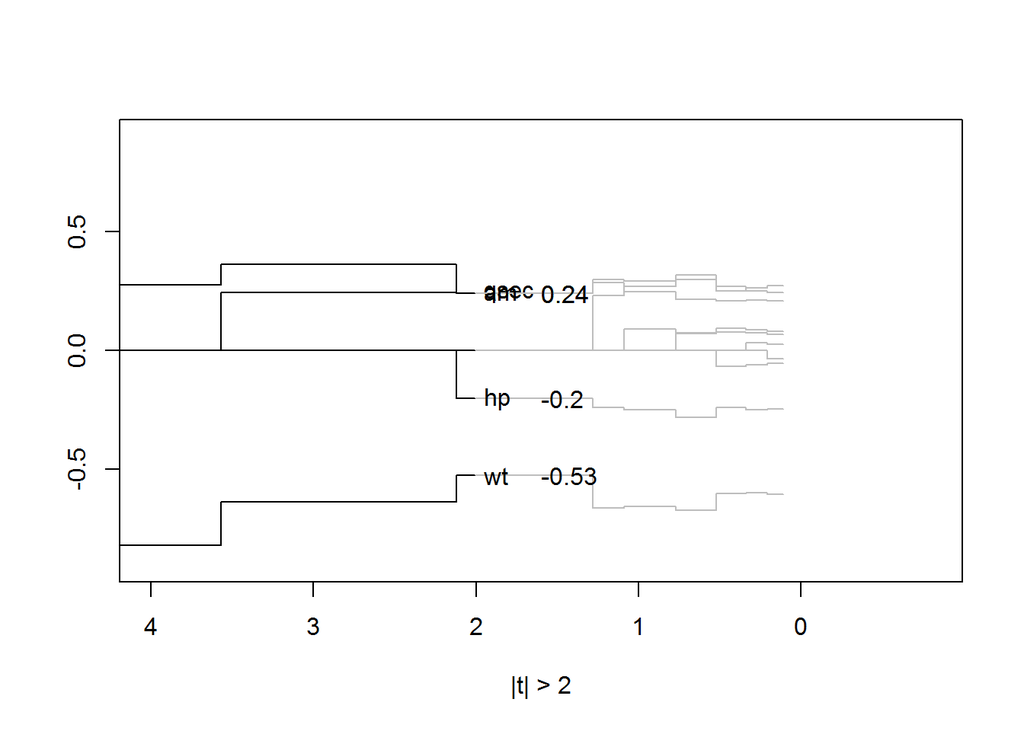

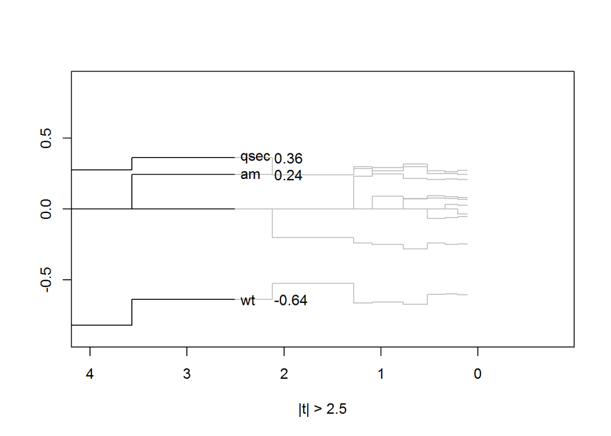

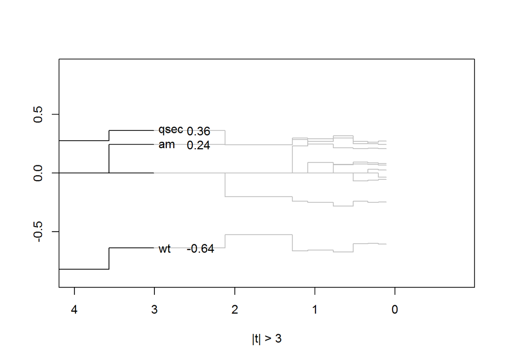

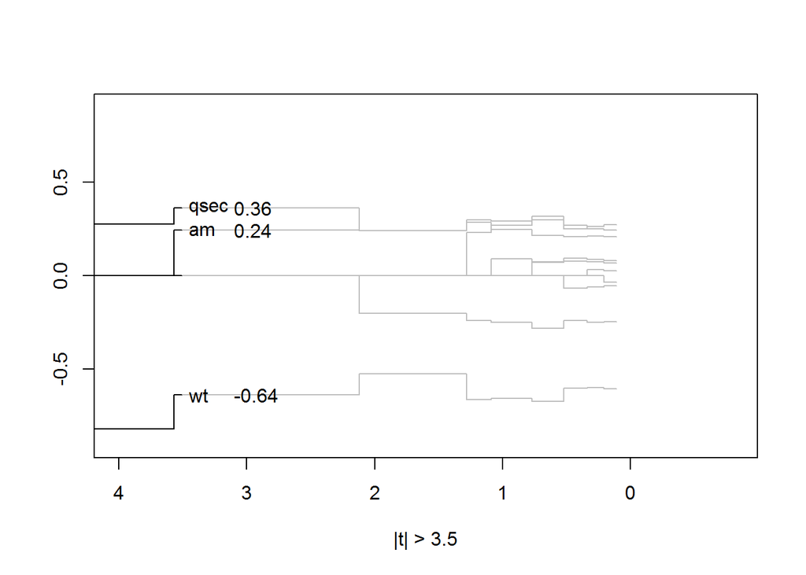

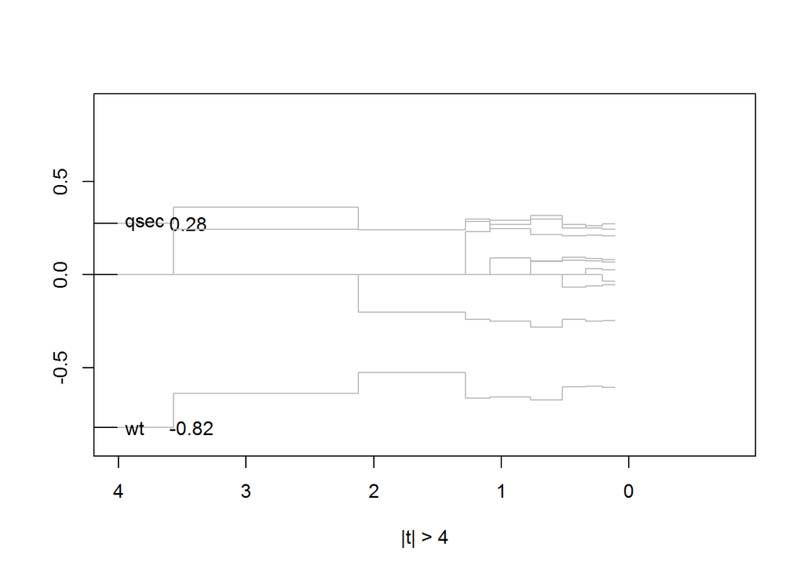

```r
for (j in seq(0, 4, by=0.5)) {
  plot(m3$tint, m3$estimate, type="n", xlim=c(4, -0.8), ylim=c(-0.9, 0.9),
       xlab=paste("|t| >", j), ylab=" ")
  for (i in unique(m0$term)) {
    sb <- which(m3$term==i)
    lines(m3$tint[sb], m3$estimate[sb], type="s", col="gray")
    sb <- which(m3$term==i & m3$tint > j)
    lines(m3$tint[sb], m3$estimate[sb], type="s", col="black")
    if (m3$estimate[sb[1]] != 0) {
      text(j-0.4, m3$estimate[sb[1]], round(m3$estimate[sb[1]],2), adj=0)
      text(j-0.05, m3$estimate[sb[1]], m3$term[sb[1]], adj=0)
    }
  }
  sb <- which(m3$tint > j & abs(m3$estimate) > 0)
}
```

You can get more complicated than this. Although the lasso regression model does fairly well, it can sometimes get in a bit of trouble if there are several variables which are highly intercorrelated and which all predict the dependent variable with about the same strength. You might find better performance with Elastic Net regression, a hybrid model that combines some of the features of ridge regression with lasso regression.

Save everything for possible re-use.

```r
save.image("lasso.RData")
load("backup.RData")
```